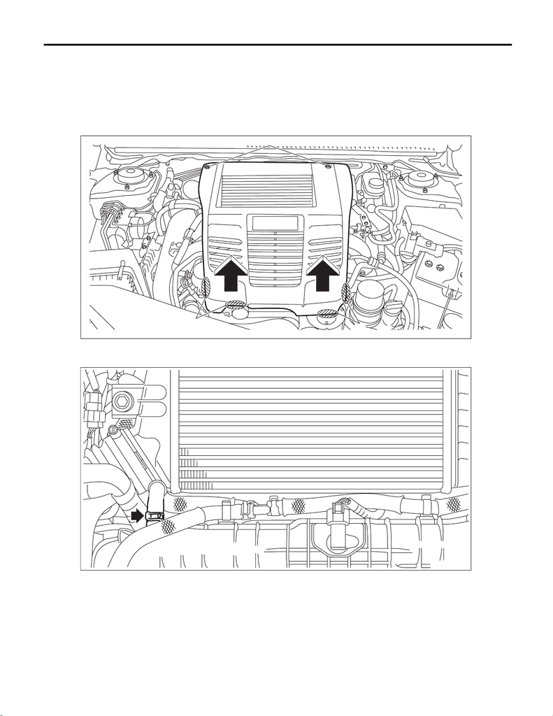

Intake Manifold Vacuum

MECHANICAL

5. Intake Manifold Vacuum

A: INSPECTION

1) Remove the collector cover.

(1) Remove the clips (A).

(2) Hold the shaded area (B) by hand and carefully pull the RH side (C) upward.

(3) Hold the shaded area (D) by hand and carefully pull the LH side (E) upward.

2) Warm up the engine.

3) Disconnect the brake booster vacuum hose from the intake manifold.

EX-03204

(A)

(B)

(C)

(E)

(D)

ME-07898

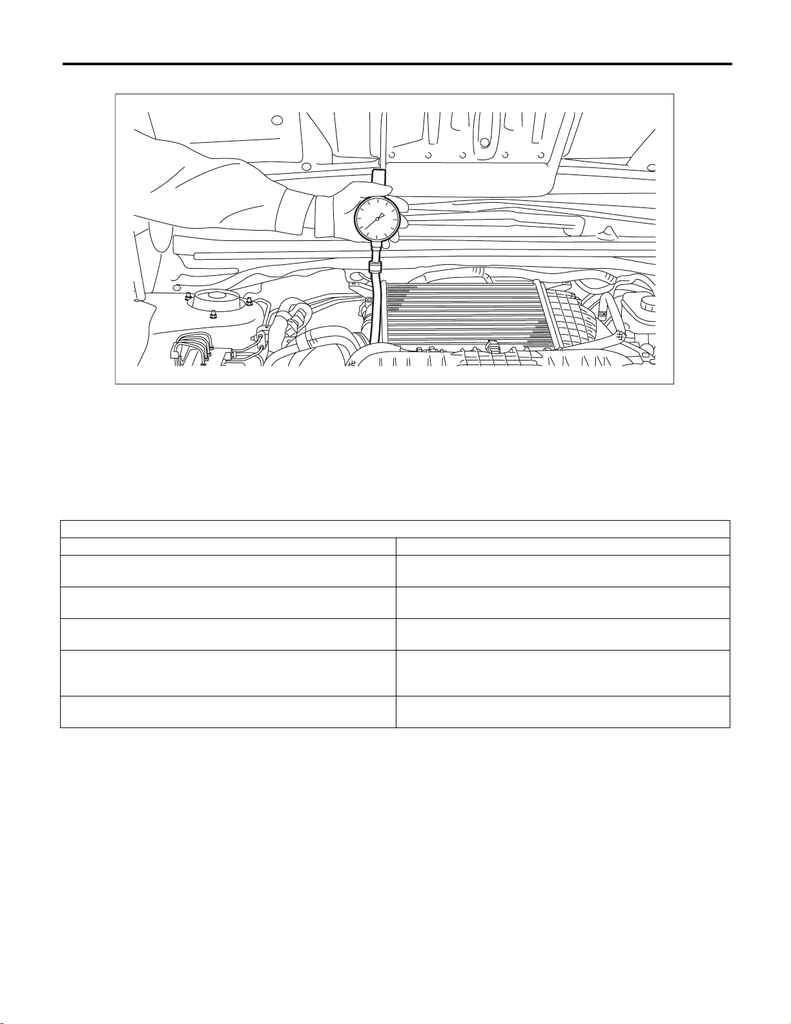

Intake Manifold Vacuum

MECHANICAL

4) Connect the vacuum gauge to the intake manifold.

5) Keep the engine at idle speed and read the vacuum gauge indication.

NOTE:

Condition of engine inside can be diagnosed by observing the behavior of the vacuum gauge needle as de-

scribed in table below.

Intake manifold vacuum (at idling, A/C OFF):

Standard

–60.0 kPa (–450 mmHg, –17.72 inHg) or more

6) After inspection, install the related parts in the reverse order of removal.

Diagnosis of engine condition by inspection of intake manifold vacuum

Vacuum gauge needle behavior Possible engine condition

1. Needle is steady but lower than standard value. This ten-

dency becomes more evident as engine temperature rises.

Leakage around intake manifold gasket, disconnection or dam-

age of vacuum hose

2. Needle intermittently drops to position lower than standard

value.

Leakage around cylinder

3. Needle drops suddenly and intermittently from standard

value.

Sticky valve

4. When engine speed is gradually increased, needle begins to

vibrate rapidly at certain speed, and then vibration increases as

engine speed increases.

Weak or broken valve springs

5. Needle vibrates above and below standard value in narrow

range.

Defective ignition system

ME-07899